# Homework 1: Python, Jupyter, and Github

In this class, we'll make extensive use of:

- Python for data processing and visualization
- Jupyter notebooks for interactive coding
- Github for managing code and other files

In this homework, you'll demo your `conda` environment, test out a few plots, and upload your notebook to Github.

## Demo 1: Anaconda environment

Run the following code to demo the name of your conda environment:

```python
import os
print('My current conda environment is: '+os.environ['CONDA_DEFAULT_ENV'])
```

```
My current conda environment is: cs185c
```

## Demo 2: Python Packages

In this course, we will make use of several data processing and visualization packages. Import them here to ensure they work:

```python
# import some packages to ensure they work
import numpy as np
import matplotlib.pyplot as plt
import xarray as xr
import netCDF4 as nc4
import cartopy.crs as ccrs
import cartopy.feature as cfeature
```

For a sneak peak, run the following code blocks to make a cool map of sea surface temperature on the globe:

```python
ds = xr.open_dataset('SST_20150101.nc',decode_times=False)
longitude = ds['LONGITUDE_T'][:]
latitude = ds['LATITUDE_T'][:]
SST = ds['SST'][:,:,:]
ds.close()
SST = SST[0,:,:]
```

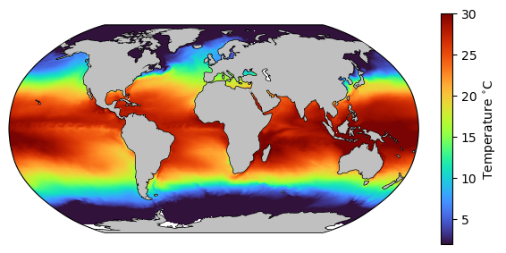

```python
# make a plot of sst here
plt.figure()
ax = plt.axes(projection=ccrs.Robinson())
C = plt.pcolormesh(longitude, latitude, SST,
                   transform=ccrs.PlateCarree(),
                   vmin=2, vmax=30, cmap='turbo')
plt.colorbar(C, label='Temperature $^{\circ}$C', fraction=0.026)
plt.gca().add_feature(cfeature.LAND, zorder=99, facecolor='silver')
plt.gca().coastlines()
plt.show()
```

## Problem 1.3: Course Github Repository

In this course, all of the course materials will be managed and turned in on Github. If you haven't already done so, make an account Github account and create a repository for this class following the instructions [HERE](https://profmikewood.github.io/ocean_modeling_book/getting_started/setting_up_a_github_repository.html).

In your repository, make a directory for `homework` and another subdirectory for `homework 1`, and upload this folder to your Github repository. When your repository is ready it should look like the homework directory in my example [spring2025](https://github.com/ProfMikeWood/cs185c_spring2025/tree/main/homework) repository.